# Advisor meeting

2024-02-14

## Determining main model: WEBL

- meanI_WEBL_poly: gweight_scaled ~ poly(meanmaxtempI_scaled,2,raw = TRUE) * habitat + poly(meanmintempI_scaled,2) * habitat + age + juliandate_scaled + (1|year) + (1|site/attempt_id)
- meanI_WEBL_linear: gweight_scaled ~ poly(meanmaxtempI_scaled,1,raw = TRUE) * habitat + poly(meanmaxtempI_scaled,2,raw = TRUE) + poly(meanmintempI_scaled,2) * habitat + age + juliandate_scaled + (1|year) + (1|site/attempt_id)
- meanI_WEBL_noint: gweight_scaled ~ poly(meanmaxtempI_scaled,1,raw = TRUE) + habitat + poly(meanmaxtempI_scaled,2,raw = TRUE) + poly(meanmintempI_scaled,2) * habitat + age + juliandate_scaled + (1|year) + (1|site/attempt_id)

### Is interaction significant?

| model | npar | AIC | BIC | logLik | deviance | Chisq | Df | Pr(>Chisq) |
| --- | --- | --- | --- | --- | --- | --- | --- | --- |
| no int | 20 | 985.8943 | 1067.539 | -472.9471 | 945.8943 | NA | NA | NA |
| linear int | 23 | 938.6510 | 1032.542 | -446.3255 | 892.6510 | 53.243335 | 3 | 1.626926e-11 |
| sq int | 26 | 939.0869 | 1045.225 | -443.5435 | 887.0869 | 5.564033 | 3 | 1.348585e-01 |

### Is squared term significant?

| model | npar | AIC | BIC | logLik | deviance | Chisq | Df | Pr(>Chisq) |
| --- | --- | --- | --- | --- | --- | --- | --- | --- |
| no temp | 18 | 985.5121 | 1058.992 | -474.7561 | 949.5121 | NA | NA | NA |
| linear temp | 22 | 937.2199 | 1027.029 | -446.6100 | 893.2199 | 56.292177 | 4 | 1.741363e-11 |
| sq temp | 26 | 939.0869 | 1045.225 | -443.5435 | 887.0869 | 6.133011 | 4 | 1.894327e-01 |

| model | npar | AIC | BIC | logLik | deviance | Chisq | Df | Pr(>Chisq) |
| --- | --- | --- | --- | --- | --- | --- | --- | --- |
| no sq | 22 | 937.2199 | 1027.029 | -446.6100 | 893.2199 | NA | NA | NA |
| linear int | 23 | 938.6510 | 1032.542 | -446.3255 | 892.6510 | 0.5689777 | 1 | 0.4506654 |

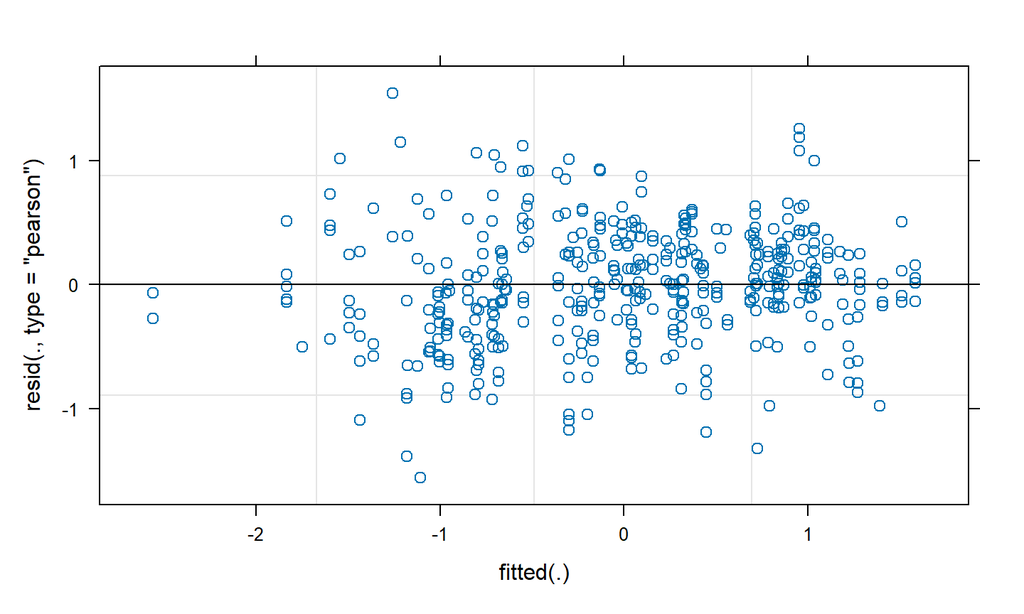

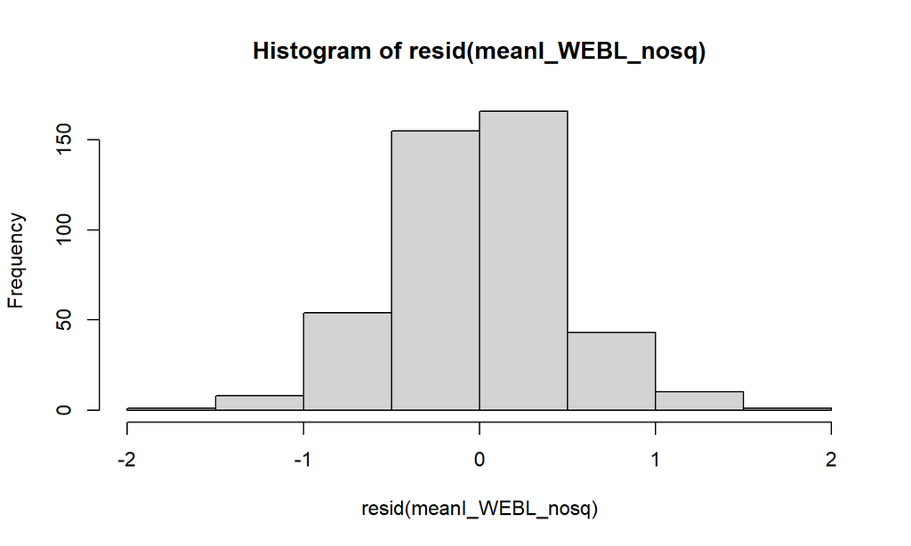

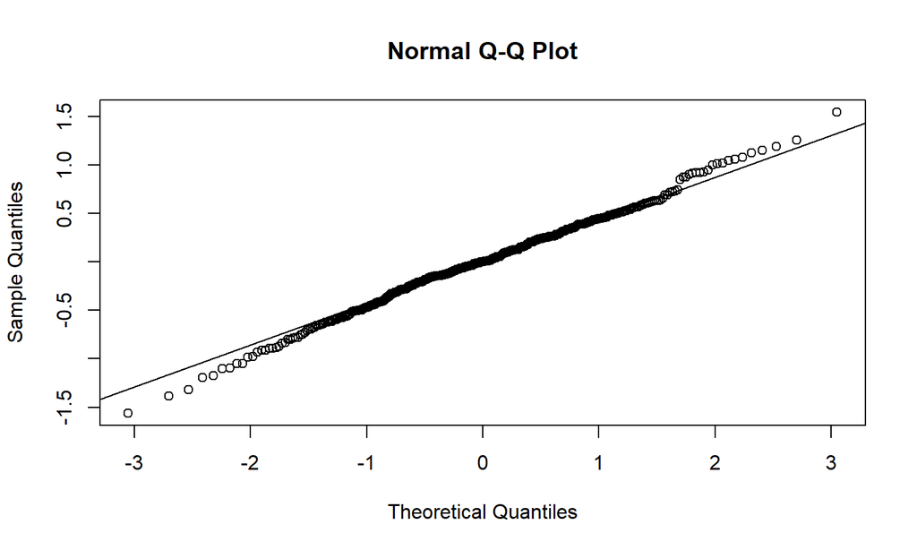

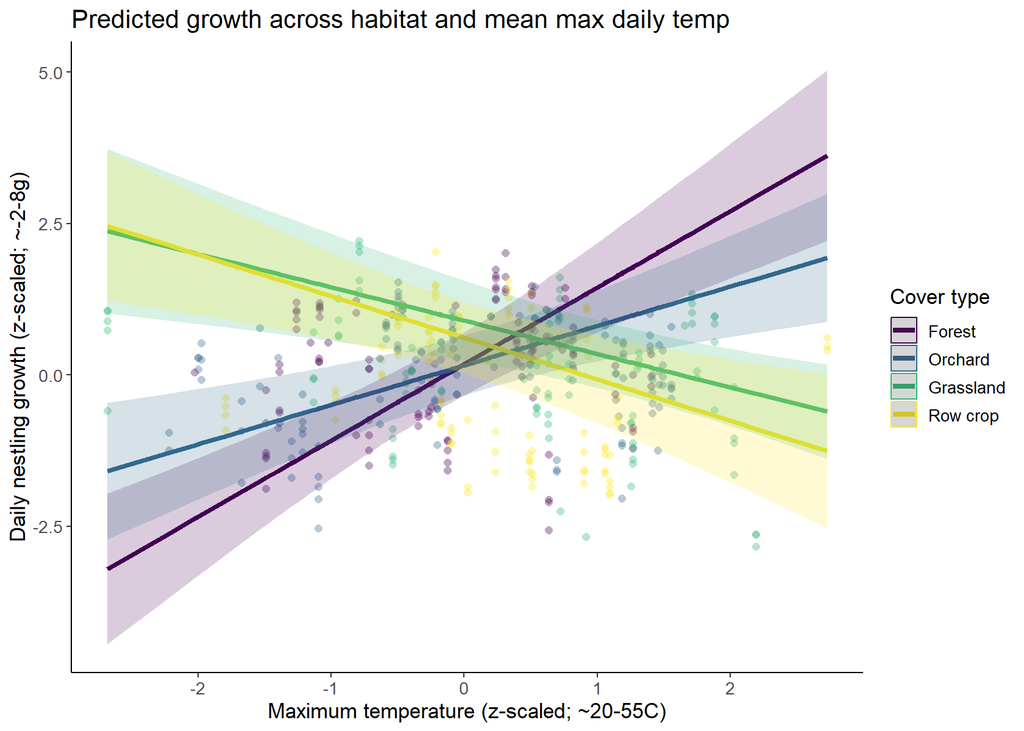

| Predictor | Estimate | SE | P-value |
| --- | --- | --- | --- |
| (Intercept) | 2.96 | 0.28 | 0.0000 |
| meanmaxtempI_scaled | 1.26 | 0.23 | 0.0000 |
| habitatOrchard | -0.11 | 0.32 | 0.7326 |
| habitatGrassland | -0.41 | 0.36 | 0.2634 |
| habitatRow crop | -0.30 | 0.33 | 0.3700 |
| poly(meanmintempI_scaled, 2)1 | -36.35 | 8.56 | 0.0000 |
| poly(meanmintempI_scaled, 2)2 | -6.72 | 6.64 | 0.3128 |
| age | -0.22 | 0.01 | 0.0000 |
| juliandate_scaled | -0.42 | 0.13 | 0.0030 |
| meanmaxtempI_scaled:habitatOrchard | -0.61 | 0.29 | 0.0379 |
| meanmaxtempI_scaled:habitatGrassland | -1.81 | 0.29 | 0.0000 |
| meanmaxtempI_scaled:habitatRow crop | -1.95 | 0.31 | 0.0000 |
| habitatOrchard:poly(meanmintempI_scaled, 2)1 | 42.55 | 11.65 | 0.0003 |
| habitatGrassland:poly(meanmintempI_scaled, 2)1 | 70.12 | 12.35 | 0.0000 |
| habitatRow crop:poly(meanmintempI_scaled, 2)1 | 58.69 | 11.40 | 0.0000 |
| habitatOrchard:poly(meanmintempI_scaled, 2)2 | 8.20 | 7.59 | 0.2816 |
| habitatGrassland:poly(meanmintempI_scaled, 2)2 | -24.94 | 9.45 | 0.0088 |
| habitatRow crop:poly(meanmintempI_scaled, 2)2 | -12.97 | 8.35 | 0.1226 |

## Determining main model: TRES

- meanI_TRES: gweight_scaled ~ poly(meanmaxtempI_scaled,2,raw = TRUE) * habitat + poly(meanmintempI_scaled,2) * habitat + age + juliandate_scaled + (1|year) + (1|site/attempt_id)
- meanI_TRES_linear: gweight_scaled ~ poly(meanmaxtempI_scaled,1,raw = TRUE) * habitat + poly(meanmaxtempI_scaled,2,raw = TRUE) + poly(meanmintempI_scaled,2) * habitat + age + juliandate_scaled + (1|year) + (1|site/attempt_id)
- meanI_TRES_noint: gweight_scaled ~ poly(meanmaxtempI_scaled,2,raw = TRUE) + habitat + poly(meanmintempI_scaled,2) * habitat + age + juliandate_scaled + (1|year) + (1|site/attempt_id)

### Is interaction significant?

| model | npar | AIC | BIC | logLik | deviance | Chisq | Df | Pr(>Chisq) |
| --- | --- | --- | --- | --- | --- | --- | --- | --- |
| no int | 20 | 839.6989 | 916.6854 | -399.8495 | 799.6989 | NA | NA | NA |
| linear int | 23 | 818.7154 | 907.2499 | -386.3577 | 772.7154 | 26.983490 | 3 | 5.934462e-06 |
| sq int | 26 | 821.8212 | 921.9037 | -384.9106 | 769.8212 | 2.894219 | 3 | 4.082238e-01 |

### Is squared temp term significant?

| model | npar | AIC | BIC | logLik | deviance | Chisq | Df | Pr(>Chisq) |
| --- | --- | --- | --- | --- | --- | --- | --- | --- |
| no temp | 18 | 839.5696 | 908.8575 | -401.7848 | 803.5696 | NA | NA | NA |
| linear temp | 22 | 819.2378 | 903.9230 | -387.6189 | 775.2378 | 28.331779 | 4 | 1.068317e-05 |
| sq temp | 26 | 821.8212 | 921.9037 | -384.9106 | 769.8212 | 5.416622 | 4 | 2.471562e-01 |

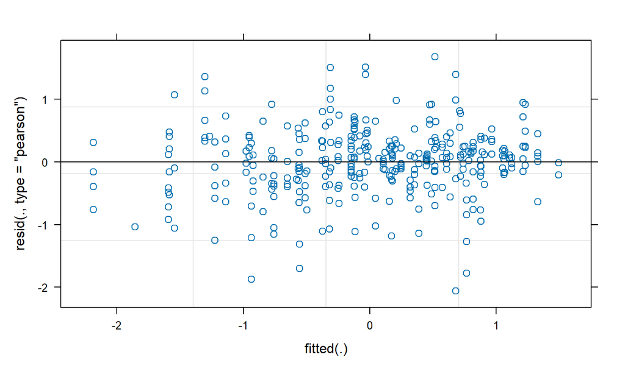

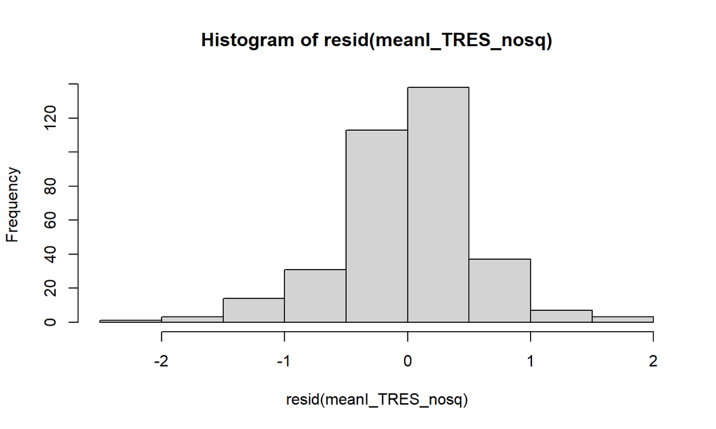

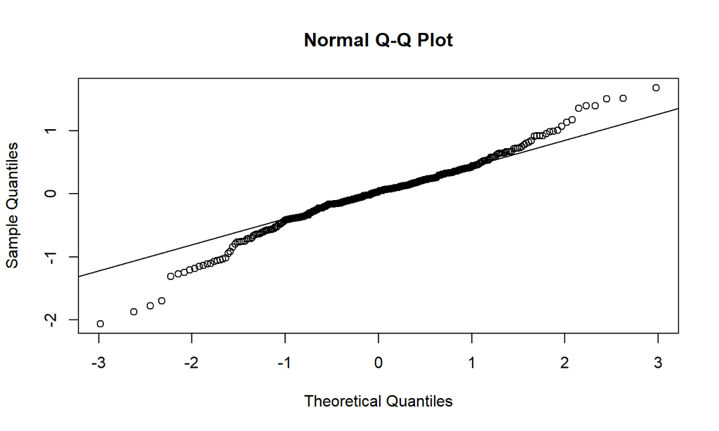

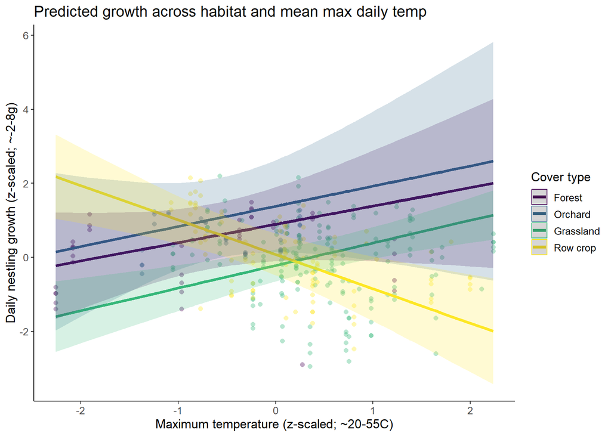

| Predictor | Estimate | SE | P-value |
| --- | --- | --- | --- |
| (Intercept) | 1.49 | 0.50 | 0.0036 |
| meanmaxtempI_scaled | 0.49 | 0.37 | 0.1813 |
| habitatOrchard | 0.75 | 0.71 | 0.3000 |
| habitatGrassland | -0.52 | 0.53 | 0.3283 |
| habitatRow crop | 0.83 | 0.62 | 0.1830 |
| poly(meanmintempI_scaled, 2)1 | 15.77 | 13.58 | 0.2482 |
| poly(meanmintempI_scaled, 2)2 | -29.37 | 9.56 | 0.0026 |
| age | -0.11 | 0.02 | 0.0000 |
| juliandate_scaled | -0.18 | 0.14 | 0.2172 |
| meanmaxtempI_scaled:habitatOrchard | 0.05 | 0.65 | 0.9397 |
| meanmaxtempI_scaled:habitatGrassland | 0.11 | 0.38 | 0.7644 |
| meanmaxtempI_scaled:habitatRow crop | -1.42 | 0.44 | 0.0015 |
| habitatOrchard:poly(meanmintempI_scaled, 2)1 | 3.26 | 29.48 | 0.9123 |
| habitatGrassland:poly(meanmintempI_scaled, 2)1 | -26.11 | 14.14 | 0.0675 |
| habitatRow crop:poly(meanmintempI_scaled, 2)1 | -54.20 | 22.80 | 0.0186 |
| habitatOrchard:poly(meanmintempI_scaled, 2)2 | 13.34 | 22.88 | 0.5621 |
| habitatGrassland:poly(meanmintempI_scaled, 2)2 | 20.39 | 10.13 | 0.0463 |
| habitatRow crop:poly(meanmintempI_scaled, 2)2 | 62.36 | 13.65 | 0.0000 |

## Beginning cort explorations

Data prep:

```r
g <- g %>% mutate(cort_s1 = cort_s1/1000,
                  cort_s2 = cort_s2/1000,
                  cort_s1_mother = cort_s1_mother/1000,
                  cort_s2_mother = cort_s2_mother/1000,
                  condition = weight/tarsus)
c <- read_rds("../data/cort_with_id.rds")  %>%
  mutate(condition = weight/tarsus,
         s1 = s1/1000,
         s2 = s2/1000,
         cort_s1_mother = cort_s1_mother/1000,
         cort_s2_mother = cort_s2_mother/1000)
```

## WEBL models

### Baseline

Model: s1_scaled ~ brood_size_scaled + condition_scaled + habitat

```
##
## Call:
## lm(formula = s1_scaled ~ brood_size_scaled + condition_scaled +
##     habitat, data = c %>% filter(Sex == "F" & Age %in% c("AHY",
##     "ASY", "SY"), !is.na(s1), !is.na(brood_size), !is.na(condition),
##     Species == "WEBL") %>% mutate(across(c(s1, brood_size, condition),
##     ~scale(.x)[, 1], .names = "{.col}_scaled")))
##
## Residuals:
##     Min      1Q  Median      3Q     Max
## -1.1721 -0.4687 -0.2498  0.1338  3.0715
##
## Coefficients:
##                   Estimate Std. Error t value Pr(>|t|)
## (Intercept)        -0.4453     0.2575  -1.729   0.0919 .
## brood_size_scaled  -0.3140     0.1444  -2.174   0.0360 *
## condition_scaled    0.3662     0.1526   2.400   0.0214 *
## habitatOrchard      1.0696     0.3981   2.687   0.0106 *
## habitatGrassland    0.2585     0.3748   0.690   0.4945
## habitatRow crop     0.5537     0.4115   1.346   0.1864
## ---
## Signif. codes:  0 '***' 0.001 '**' 0.01 '*' 0.05 '.' 0.1 ' ' 1
##
## Residual standard error: 0.9093 on 38 degrees of freedom
## Multiple R-squared:  0.2694, Adjusted R-squared:  0.1732
## F-statistic: 2.802 on 5 and 38 DF,  p-value: 0.02996
```

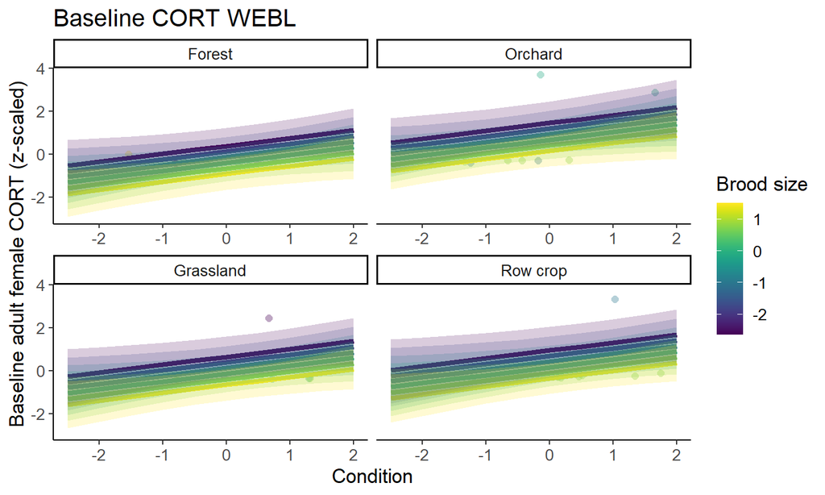

### Stressed

Model: s2_scaled ~ brood_size_scaled + condition_scaled + habitat

```
##
## Call:
## lm(formula = s2_scaled ~ brood_size_scaled + condition_scaled +
##     habitat, data = c %>% filter(Sex == "F" & Age %in% c("AHY",
##     "ASY", "SY"), !is.na(s2), !is.na(brood_size), !is.na(condition),
##     Species == "WEBL") %>% mutate(across(c(s2, brood_size, condition),
##     ~scale(.x)[, 1], .names = "{.col}_scaled")))
##
## Residuals:
##     Min      1Q  Median      3Q     Max
## -1.7289 -0.3995 -0.1774  0.1216  3.4278
##
## Coefficients:
##                    Estimate Std. Error t value Pr(>|t|)
## (Intercept)       -0.143904   0.255992  -0.562   0.5771
## brood_size_scaled -0.379657   0.145808  -2.604   0.0128 *
## condition_scaled   0.131484   0.152938   0.860   0.3949
## habitatOrchard     0.357964   0.389201   0.920   0.3631
## habitatGrassland  -0.003701   0.376371  -0.010   0.9922
## habitatRow crop    0.279147   0.415196   0.672   0.5051
## ---
## Signif. codes:  0 '***' 0.001 '**' 0.01 '*' 0.05 '.' 0.1 ' ' 1
##
## Residual standard error: 0.9547 on 41 degrees of freedom
## Multiple R-squared:  0.1877, Adjusted R-squared:  0.0886
## F-statistic: 1.894 on 5 and 41 DF,  p-value: 0.1163
```

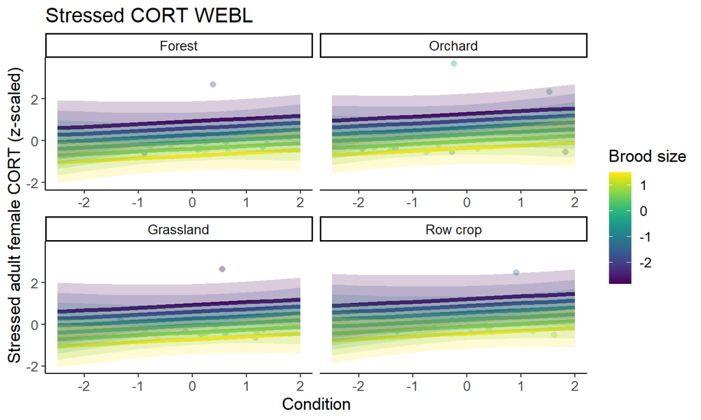

### Instead of habitat as factor, temp * humidity * canopy cover: by condition and brood size

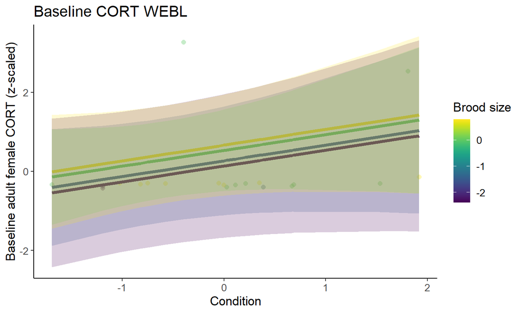

### By temp and brood size

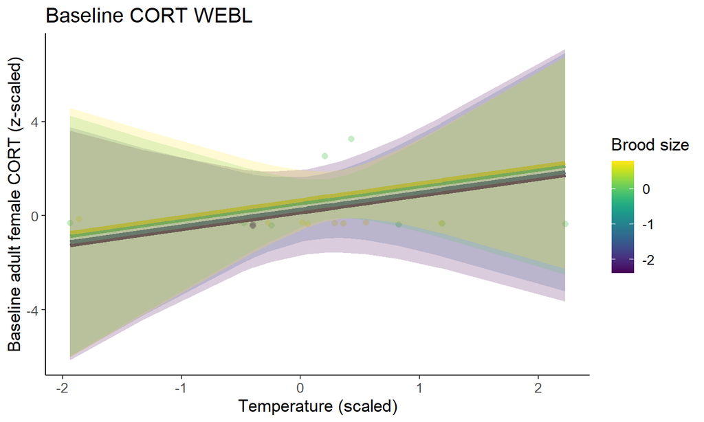

### Stressed CORT WEBL: by condition and brood size

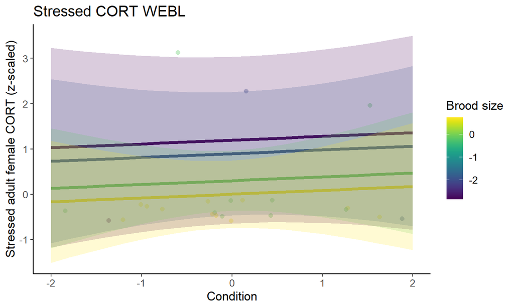

### Stressed CORT WEBL: by temp and brood size

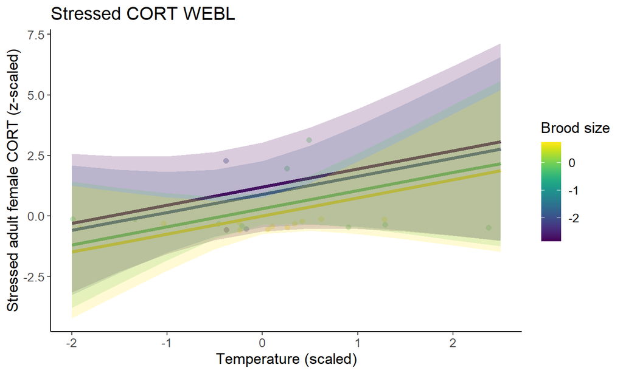

## TRES models

Baseline model: s1_scaled ~ brood_size_scaled + condition_scaled + habitat

```
##
## Call:
## lm(formula = s1_scaled ~ brood_size_scaled + condition_scaled +
##     habitat, data = c %>% filter(Sex == "F" & Age %in% c("AHY",
##     "ASY", "SY"), !is.na(s1), !is.na(brood_size), !is.na(condition),
##     Species == "TRES") %>% mutate(across(c(s1, brood_size, condition),
##     ~scale(.x)[, 1], .names = "{.col}_scaled")))
##
## Residuals:
##      Min       1Q   Median       3Q      Max
## -1.62666 -0.42622 -0.07443  0.47858  1.81273
##
## Coefficients:
##                   Estimate Std. Error t value Pr(>|t|)
## (Intercept)        0.70258    0.49181   1.429   0.1635
## brood_size_scaled -0.09211    0.15890  -0.580   0.5665
## condition_scaled   0.25595    0.17573   1.456   0.1556
## habitatOrchard    -2.33551    0.86370  -2.704   0.0112 *
## habitatGrassland  -0.54011    0.55487  -0.973   0.3381
## habitatRow crop   -0.90832    0.55035  -1.650   0.1093
## ---
## Signif. codes:  0 '***' 0.001 '**' 0.01 '*' 0.05 '.' 0.1 ' ' 1
##
## Residual standard error: 0.935 on 30 degrees of freedom
## Multiple R-squared:  0.2507, Adjusted R-squared:  0.1258
## F-statistic: 2.007 on 5 and 30 DF,  p-value: 0.1063
```

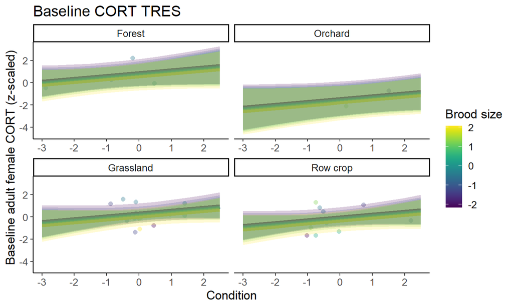

### Stressed CORT TRES

Model: s2_scaled ~ brood_size_scaled + condition_scaled + habitat

```
##
## Call:
## lm(formula = s2_scaled ~ brood_size_scaled + condition_scaled +
##     habitat, data = c %>% filter(Sex == "F" & Age %in% c("AHY",
##     "ASY", "SY"), !is.na(s2), !is.na(brood_size), !is.na(condition),
##     Species == "TRES") %>% mutate(across(c(s2, brood_size, condition),
##     ~scale(.x)[, 1], .names = "{.col}_scaled")))
##
## Residuals:
##     Min      1Q  Median      3Q     Max
## -1.6614 -0.4593 -0.1099  0.4328  3.3290
##
## Coefficients:
##                   Estimate Std. Error t value Pr(>|t|)
## (Intercept)        -0.4506     0.4058  -1.110   0.2760
## brood_size_scaled  -0.1404     0.1820  -0.772   0.4466
## condition_scaled   -0.3377     0.1733  -1.949   0.0611 .
## habitatOrchard      0.7288     0.6407   1.137   0.2647
## habitatGrassland    0.3206     0.4755   0.674   0.5056
## habitatRow crop     0.8585     0.5403   1.589   0.1229
## ---
## Signif. codes:  0 '***' 0.001 '**' 0.01 '*' 0.05 '.' 0.1 ' ' 1
##
## Residual standard error: 0.9421 on 29 degrees of freedom
## Multiple R-squared:  0.243,  Adjusted R-squared:  0.1125
## F-statistic: 1.862 on 5 and 29 DF,  p-value: 0.1319
```

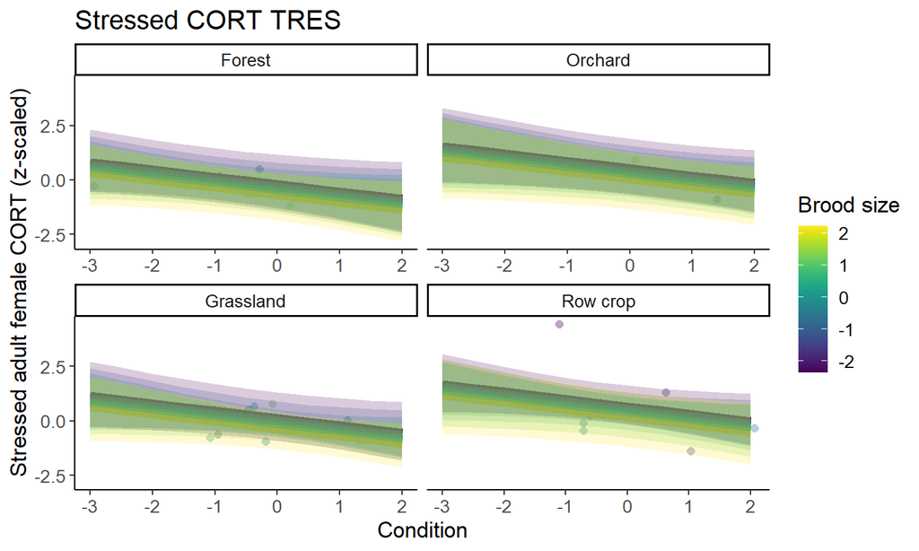

### Alternative to habitat: temp* humidity * canopy cover

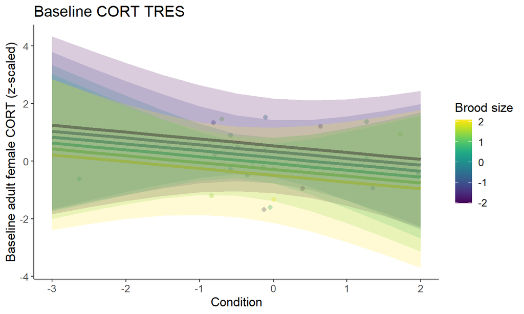

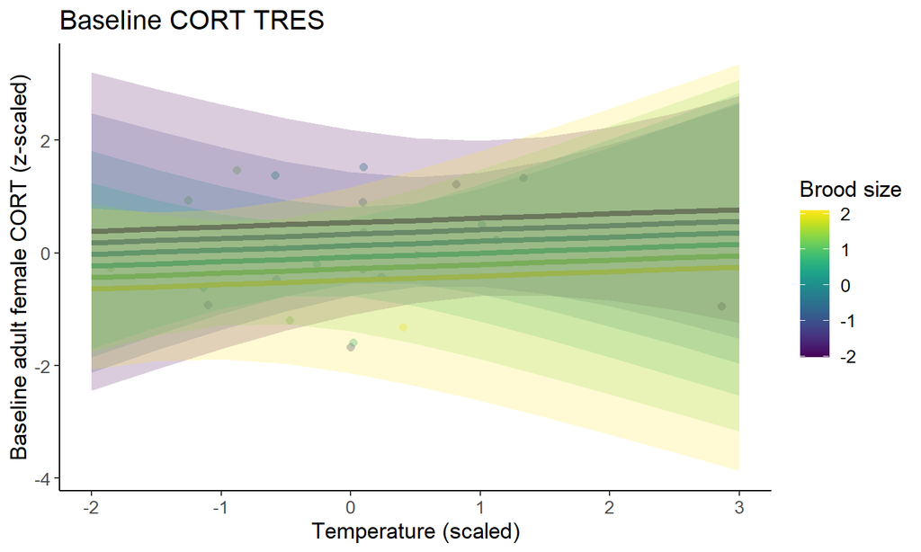

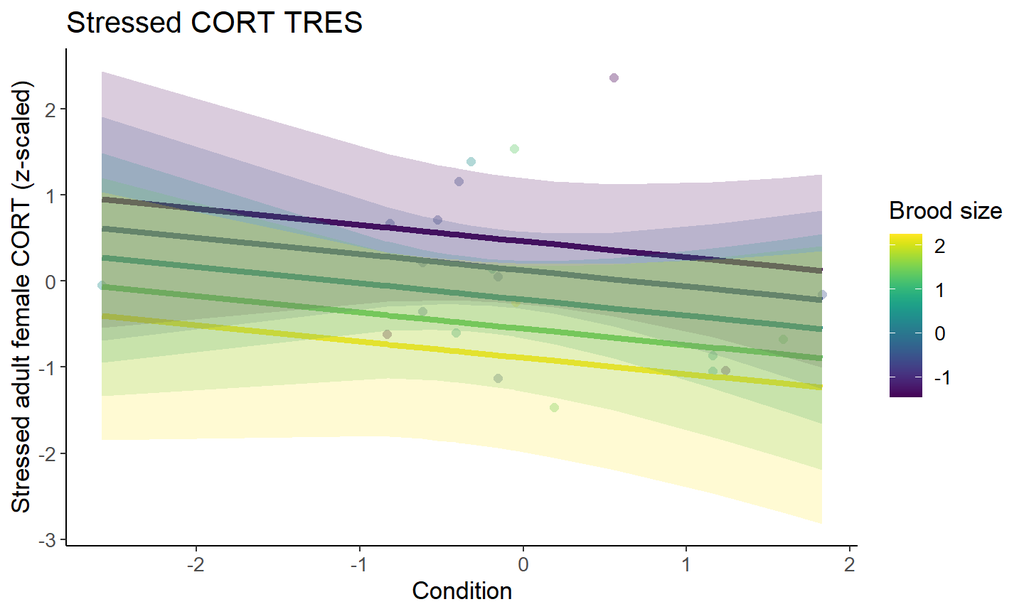

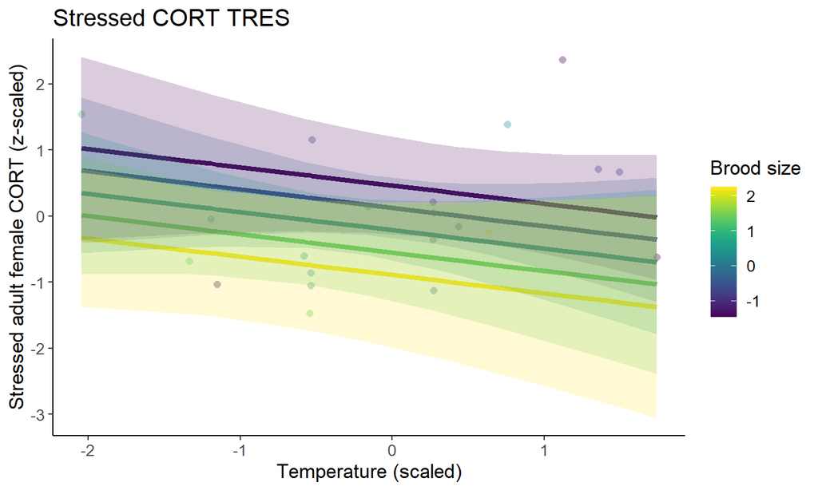

## Is there a difference between CORT among nestling sampling occasions?

### WEBL: baseline

```
##                     Df Sum Sq Mean Sq F value Pr(>F)
## factor(attempt_id)  60 159168  2652.8  23.160 <2e-16 ***
## factor(occasion)     1      9     9.3   0.081  0.776
## Residuals          136  15578   114.5
## ---
## Signif. codes:  0 '***' 0.001 '**' 0.01 '*' 0.05 '.' 0.1 ' ' 1
## 298 observations deleted due to missingness
```

### WEBL: stressed

```
##                     Df Sum Sq Mean Sq F value Pr(>F)
## factor(attempt_id)  62 351142    5664  19.441 <2e-16 ***
## factor(occasion)     1   1440    1440   4.944 0.0279 *
## Residuals          132  38454     291
## ---
## Signif. codes:  0 '***' 0.001 '**' 0.01 '*' 0.05 '.' 0.1 ' ' 1
## 300 observations deleted due to missingness
```

### TRES: baseline

```
##                    Df Sum Sq Mean Sq F value Pr(>F)
## factor(attempt_id) 43 1563.8   36.37   1.132  0.318
## factor(occasion)    1    5.5    5.45   0.170  0.682
## Residuals          70 2249.0   32.13
## 276 observations deleted due to missingness
```

### TRES: stressed

```
##                    Df Sum Sq Mean Sq F value Pr(>F)
## factor(attempt_id) 39  26400   676.9    1.59 0.0644 .
## factor(occasion)    1   2303  2302.8    5.41 0.0244 *
## Residuals          47  20007   425.7
## ---
## Signif. codes:  0 '***' 0.001 '**' 0.01 '*' 0.05 '.' 0.1 ' ' 1
## 303 observations deleted due to missingness
```

My conclusion: Occasion does not seem to matter for baseline CORT but it does for stressed CORT.

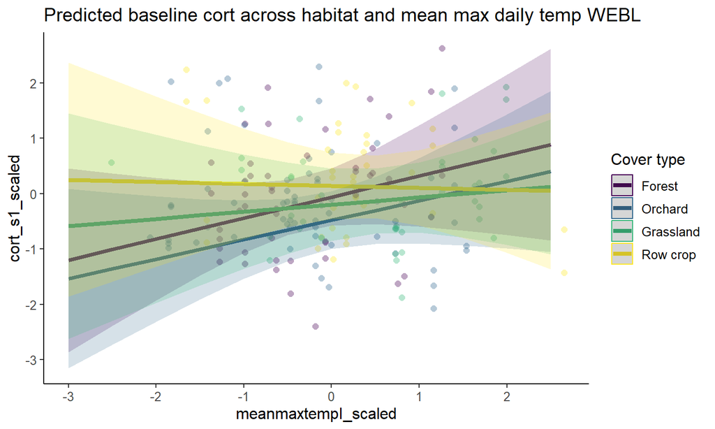

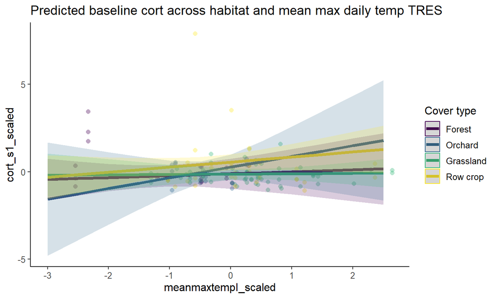

## Condition models: Nestling WEBL

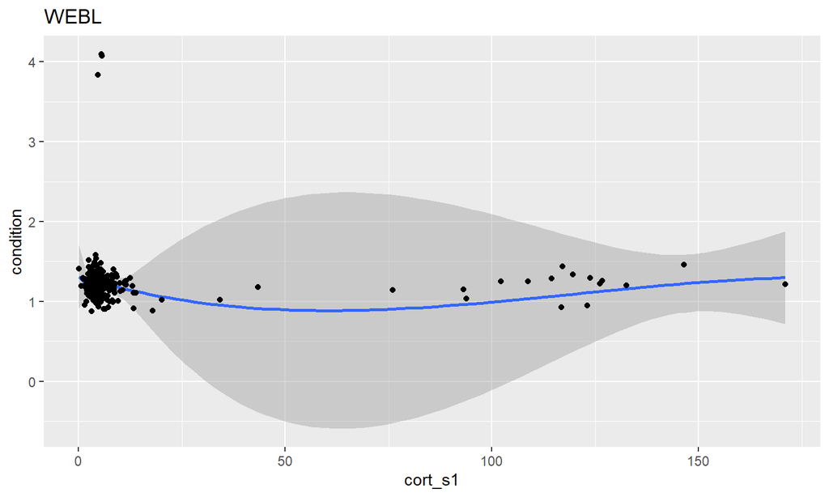

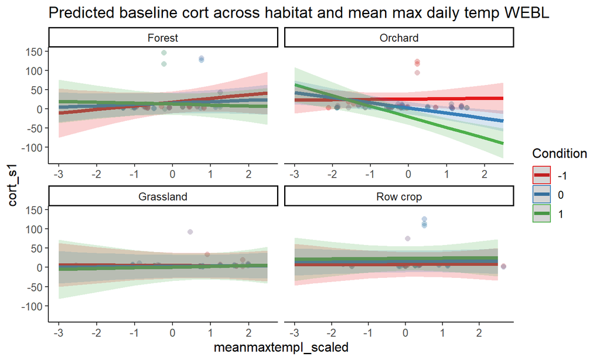

## Condition models: Nestling TRES

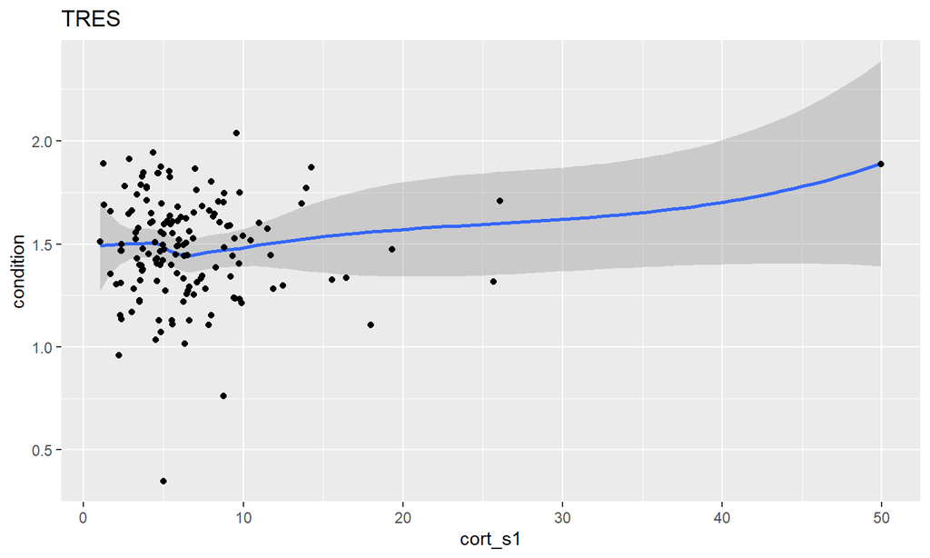

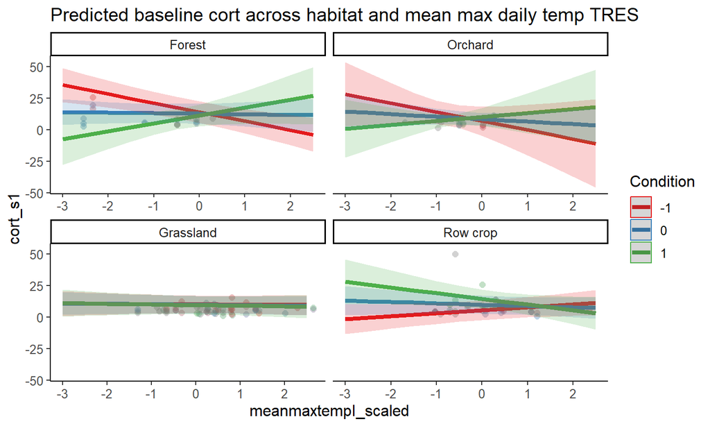